# Quiz 2

2023-11-28

## 시험시간: 2023년 11월 28일 13:10 ~ 14:10

## 제출: Html, Rmd 파일을 .zip으로 압축해 etl에 제출

#### 주의사항

- 전자기기(휴대폰 등)나 메신저(메일, 카톡 등)는 시험 중 절대로 사용할 수 없음. 사용이 적발 시 부정행위로 간주해 바로 퇴실조치.
- 시간 초과로 인해 제출하지 못하는 경우 책임은 수강생 본인에게 있음. 마감 시간 까지 문제를 푸는 것이 아닌, Knit과 etl 제출까지 완료해야 하므로 꼭 마지막 5~10분은 제출 준비 할 것.

```r
library(nycflights13)
library(tidyverse)
```

### Q1.`holiday.csv`는 2013년 미국의 휴일에 관한 데이터이고 `nycflights13` package의 `flights`는 2013년 뉴욕에서 출발한 항공편에 관한 데이터이다.

#### 1-1. 미국의 휴일 중 이름에 “Birthday”가 포함되는 날의 개수를 구하시오.

#### 1-2. Federal Holiday에 뉴욕에서 출발한 항공편의 개수를 구하시오.

- 조건 1. `holiday`와 `flights`를 `holiday`를 기준으로 merge하시오.
- 조건 2. type이 Federal Holiday인 날들의 항공편 개수를 세어 내림차순으로 정렬하시오. table을 반드시 출력할 것.

### A1.

1-1.

```r
holiday <- read_csv("./holiday.csv")
sum(str_detect(holiday$name, "Birthday"))
```

```
## [1] 17
```

1-2.

```r
holiday_fed <- holiday %>% filter(type == "Federal Holiday")
ans1 <- left_join(x = holiday_fed, y = flights, by = c("year", "month", "day")) %>%
  group_by(name) %>% summarise(count = n()) %>% arrange(desc(count))
ans1
```

```
## # A tibble: 10 × 2
##    name                       count
##    <chr>                      <int>
##  1 Veterans Day                 983
##  2 Memorial Day                 932
##  3 Labor Day                    929
##  4 Martin Luther King Jr. Day   926
##  5 Columbus Day                 915
##  6 Presidents' Day              899
##  7 Christmas Day                896
##  8 New Year's Day               842
##  9 Independence Day             737
## 10 Thanksgiving Day             634
```

### Q2. 남여 커플의 MBTI가 어떻게 분포해있는지 알아보고자 한다. `raw_MBTI.txt`는 3만 쌍의 커플 각각의 MBTI에 대한 raw data 이다. A-B 형태의 raw data에서 A는 남성의 MBTI를, B는 여성의 MBTI를 나타낸다.

#### 2-1.주어진 `raw_MBTI.txt`를 불러온 후, `couple_MBTI`라는 이름의 tibble (tidy dataset) 로 변형하여 첫 다섯개 행을 출력하여라. 이를 이용해 MBTI 조합 별 커플 수의 분포를 보여주는 아래 히트맵을 조건에 맞게 구현하여라.

- 조건 1. couple_MBTI는 30000*2 크기의 tibble로 각 행에는 각 커플의 MBTI가, 각 열에는 남자, 여자의 MBTI가 입력됨.(colnames: “Man”, “Woman”)
- 조건 2. Heatmap은 x,y 축의 MBTI 순서를 아래 plot과 같게 출력해야함.

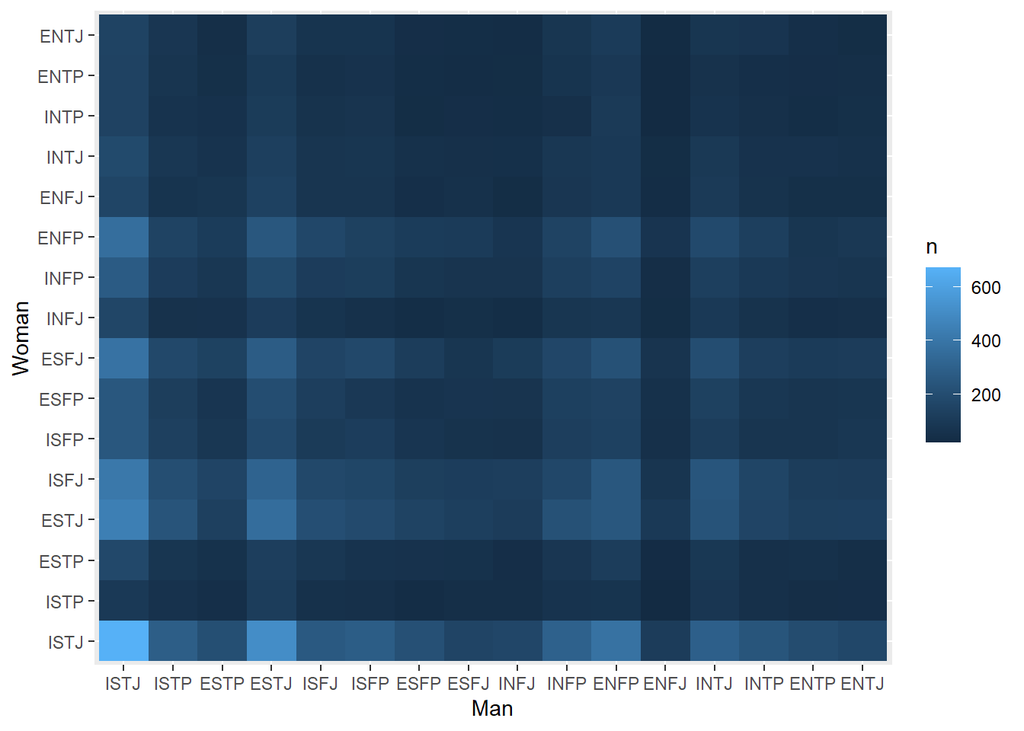

#### 2-2. 위에서 얻은 `couple_MBTI` 를 활용하여 4자리 중 일치하는 MBTI 자리수에 (ex. 남: INTP, 여: ENTJ 인 경우 일치하는 MBTI의 수는 matched = 2 이다.) 따른 커플 수 분포를 알아보고자 한다. 아래 도표를 조건에 맞게 출력하시오.

- 조건 1. column names 이 주어진 표와 일치할 것 (단, 결과 표에 해당하는 숫자를 직접 대입해서 출력하면 0점처리)
- 조건 2. 출력한 도표를 통해 MBTI 일치 여부가 커플의 분포에 영향을 미치는지를 해석할 것.
- 힌트: `>rowwise` 함수

```
## # A tibble: 5 × 2
## # Groups:   matched [5]
##   matched     n
##     <int> <int>
## 1       0  2046
## 2       1  7313
## 3       2 10866
## 4       3  7537
## 5       4  2238
```

#### A2.

2-1.

```r
raw_MBTI <- read.table("raw_MBTI.txt")
raw_MBTI2 <- raw_MBTI$V1
raw_MBTI3 <- str_split(raw_MBTI2, ",")
v <- str_split(raw_MBTI3[[1]], "-", simplify = TRUE)

MBTI <- c("ISTJ",  "ISTP", "ESTP", "ESTJ", "ISFJ", "ISFP", "ESFP", "ESFJ", "INFJ", "INFP", "ENFP", "ENFJ", "INTJ", "INTP", "ENTP", "ENTJ")
Man <- parse_factor(v[, 1], ordered = TRUE, levels = MBTI)
Woman <- parse_factor(v[, 2], ordered = TRUE, levels = MBTI)
couple_MBTI <- tibble(Man, Woman)
head(couple_MBTI,5)
```

```
## # A tibble: 5 × 2
##   Man   Woman
##   <ord> <ord>
## 1 ISFP  ESFP
## 2 INFJ  INTP
## 3 ESTJ  ESFJ
## 4 ISFP  ENFP
## 5 ISTJ  ESFP
```

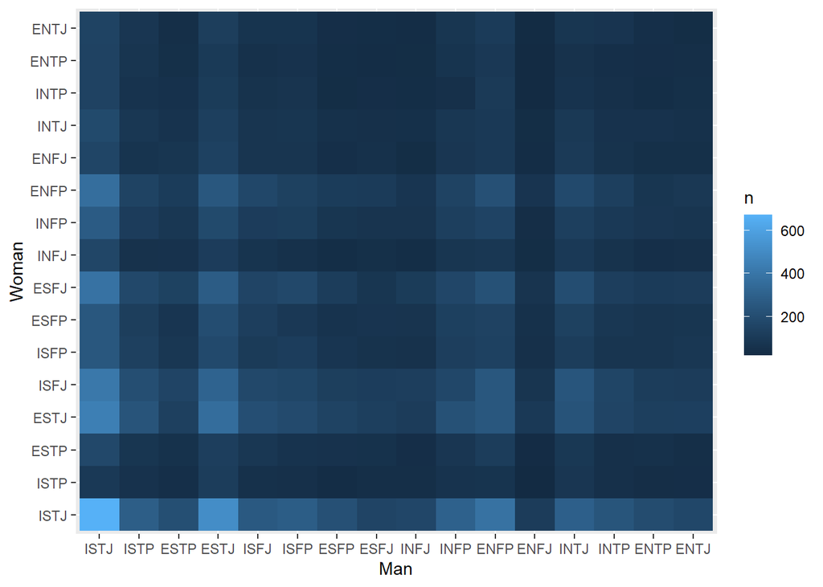

```r
couple_MBTI %>%
  count(Man, Woman) %>%
  ggplot(mapping = aes(x = Man, y = Woman)) +
  geom_tile(mapping = aes(fill = n))
```

2-2.

```r
couple_MBTI_2 <- couple_MBTI %>%
  rowwise() %>%
  mutate(matched = length(intersect(unlist(str_split(Man, "")), unlist(str_split(Woman, ""))))) %>%
  group_by(matched) %>%
  count()

couple_MBTI_2
```

```
## # A tibble: 5 × 2
## # Groups:   matched [5]
##   matched     n
##     <int> <int>
## 1       0  2046
## 2       1  7313
## 3       2 10866
## 4       3  7537
## 5       4  2238
```

해석: mbti가 커플 여부에 전혀 영향을 미치지 않는다고 가정했을 때, 각각의 자리가 일치할 확률은 독립적으로 1/2 이고 이에 따라 0,1,2,3,4 개의 자리가 일치할 확률은 1/16, 4/16, 6/16, 4/16, 1/16 으로 계산된다. 이는 위 도표의 결과와 거의 같으므로 MBTI 일치 여부가 커플 수 분포에 영향을 미친다고 보기 어렵다.

### Q3. `dplyr::starwars`에는 starwars 에 나오는 등장인물들에 대한 정보가 들어있다.이 데이터에서 이름만 추출해서 보기로 한다.

#### Q3-1. 이름에 숫자가 들어가는 등장인물들을 알아보려고 한다. 숫자를 하나라도 포함하고 있는 등장인물들을 뽑아내라.

#### Q3-2. 각 이름들을 모음 개수 별로 분류하고 각 그룹들 마다 단어의 평균 길이를 비교해 보아라.

- 조건 1. 모음의 개수를 확인할 때 대,소문자를 전부다 확인할 것.

### A3.

3-1

```r
name <- dplyr::starwars$name
df_name <- as.data.frame(name)

num_of_name <- c(as.character(0:9))
num_match <- str_c(num_of_name, collapse = "|")
more <- name[str_count(name, num_match) >= 1]
str_view(more, num_match)
```

```
## [1] │ C-<3>PO
## [2] │ R<2>-D<2>
## [3] │ R<5>-D<4>
## [4] │ IG-<8><8>
## [5] │ R<4>-P<1><7>
## [6] │ BB<8>
```

3-2

```r
df_name %>%
  mutate(vowel_count = str_count(name, "[aeiouAEIOU]"),
         total_length = str_length(name)) %>%
  group_by(vowel_count) %>%
  summarise(mean_length = mean(total_length))
```

```
## # A tibble: 9 × 2
##   vowel_count mean_length
##         <int>       <dbl>
## 1           0        4.75
## 2           1        4.57
## 3           2        6.88
## 4           3        9.24
## 5           4       11.6
## 6           5       13.8
## 7           6       14
## 8           7       17
## 9           9       21
```